# recid_score

purpose: In this notebook we explore the relations in the Risk of Recidivism data and also further examine the people on the bottom edge of the age vs compas score pt cloud

```r
library(tidyverse)
library(magrittr)
source('functions.r')
load("Table_construction.Rdata") #loading beau's version of data
```

```r
features = features %>%
  # Add other useful information:
  inner_join(
    data_before %>%
      select(person_id, screening_date, people) %>%
      unnest() %>%
      select(person_id, screening_date, race, sex, name),
    by = c("person_id","screening_date")
  ) %>%
  inner_join(features_on, by = c("person_id","screening_date")) %>%
  inner_join(outcomes, by = c("person_id","screening_date")) %>%

  # Create as many features as possible:
  mutate(
    raw_score = `Risk of Recidivism_raw_score`, # Adjust for violent/general
    decile_score = `Risk of Recidivism_decile_score`, # Adjust for violent/general
    p_jail30 = pmin(p_jail30,5),
    p_prison30 = pmin(p_jail30,5),
    p_prison = pmin(p_prison,5),
    p_probation = pmin(p_probation,5),
    race_black = if_else(race=="African-American",1,0),
    race_white = if_else(race=="Caucasian",1,0),
    race_hispanic = if_else(race=="Hispanic",1,0),
    race_asian = if_else(race=="Asian",1,0),
    race_native = if_else(race=="Native American",1,0), # race == "Other" is the baseline

    # Subscales:
    crim_inv = p_charge+
      p_jail30+
      p_prison+
      p_probation,

    # Filters (TRUE for obserations to keep)
    filt1 = `Risk of Recidivism_decile_score` != -1, `Risk of Violence_decile_score` != -1, # Filter 1
    filt3 = !is.na(current_offense_date), # Filter 3
    filt4 = current_offense_date <= current_offense_date_limit, # Filter 4
    filt5 = p_current_age > 18 & p_current_age <= 70 # Filter 5
  )
```

Modelling the COMPAS Risk of Recidivism score with a quadratic poly.

```r
features_f_age = features %>%
  filter(filt1,filt5) %>%
  select(p_current_age, raw_score)
lb_age = features_f_age %>%
  group_by(p_current_age) %>%
  #arrange(raw_score, .by_group=TRUE) %>%
  arrange(raw_score) %>%
  top_n(n=-1, wt=raw_score) # Fit lower bound on smallest value
mdl_age = lm(raw_score ~
               I(p_current_age^2) +
               p_current_age,
             data=lb_age)
# More precision for paper
summary(mdl_age)
```

```
Call:
lm(formula = raw_score ~ I(p_current_age^2) + p_current_age,
    data = lb_age)

Residuals:
     Min       1Q   Median       3Q      Max
-0.37713 -0.01170  0.01189  0.03591  0.12386

Coefficients:
                     Estimate Std. Error t value Pr(>|t|)
(Intercept)        -0.0835937  0.0670948  -1.246    0.216
I(p_current_age^2)  0.0004320  0.0000364  11.868   <2e-16 ***
p_current_age      -0.0726088  0.0032499 -22.342   <2e-16 ***
---
Signif. codes:  0 *** 0.001 ** 0.01 * 0.05 . 0.1   1

Residual standard error: 0.06507 on 98 degrees of freedom
Multiple R-squared:  0.9819,    Adjusted R-squared:  0.9816
F-statistic:  2663 on 2 and 98 DF,  p-value: < 2.2e-16
```

```r
print("Coefficients:")
```

```
[1] "Coefficients:"
```

```r
sprintf("%.20e",mdl_age$coefficients) # More precision for paper
```

```
[1] "-8.35936926784002359847e-02" "4.32026931047234277576e-04"  "-7.26087894972571729069e-02"
```

```r
## Add f(age) to features
features = features %>%
  mutate(
    f_age = predict(mdl_age, newdata=data.frame(p_current_age=p_current_age)),
    raw_score__f_age = raw_score - f_age,
    filt6 = raw_score >= f_age
  )
```

Plot age poly found

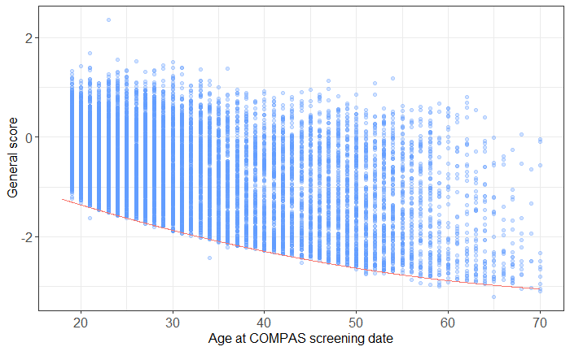

```r
## Age polynomial plot
xmin = 18
xmax = 70
xx = seq(xmin,xmax, length.out=1000)
ggplot()+
  geom_point(aes(x=p_current_age, raw_score), color="#619CFF",alpha=.3, data=features_f_age) +
  geom_line(aes(x=xx, predict(mdl_age, newdata=data.frame(p_current_age=xx))),color="#F8766D") +
  theme_bw()+
  xlim(xmin,xmax)+
  xlab("Age at COMPAS screening date") +
  ylab("General score") +
  theme(text = element_text(size=12),
        axis.text=element_text(size=12),
        legend.position="none")
```

Individuals on bottom edge

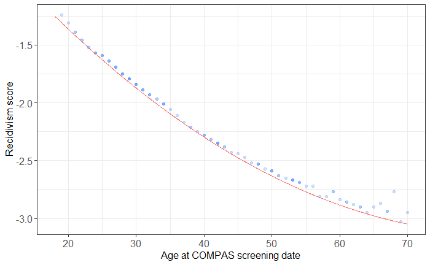

```r
#individuals on the lower bound of the age polynomial
lb_inds = features %>%
  filter(filt1,filt5, filt6) %>% #individuals who have valid scores, 18 to 70, not below lower bound
  group_by(p_current_age) %>%
  arrange(raw_score) %>%
  top_n(n=-1, wt=raw_score) # Fit lower bound on smallest value
xmin = 18
xmax = 70
xx = seq(xmin,xmax, length.out=1000)
ggplot()+
  geom_point(aes(x=p_current_age, raw_score), color="#619CFF",alpha=.3, data=lb_inds) +
  geom_line(aes(x=xx, predict(mdl_age, newdata=data.frame(p_current_age=xx))),color="#F8766D") +
  theme_bw()+
  xlim(xmin,xmax)+
  xlab("Age at COMPAS screening date") +
  ylab("Recidivism score") +
  theme(text = element_text(size=12),
        axis.text=element_text(size=12),
        legend.position="none")
```

```r
nrow(lb_inds)
```

```
[1] 127
```

Examining people in age_subset (bottom edge of age_poly vs COMPAS score pt cloud) more closely

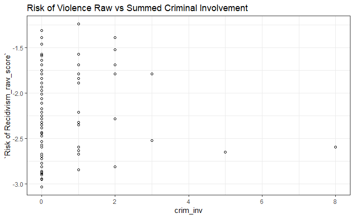

```r
ggplot(lb_inds, aes(x=crim_inv, y=`Risk of Recidivism_raw_score`)) +
     geom_point(shape=1)  +
     theme_bw()+
     ggtitle("Risk of Violence Raw vs Summed Criminal Involvement")
```

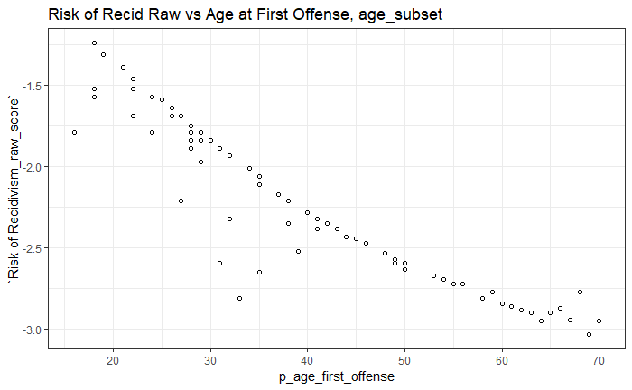

```r
ggplot(lb_inds, aes(x=p_age_first_offense, y=`Risk of Recidivism_raw_score`)) +
     geom_point(shape=1)  +
     theme_bw()+
     ggtitle("Risk of Recid Raw vs Age at First Offense, age_subset")
```

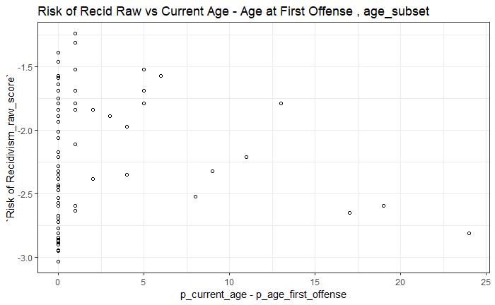

```r
ggplot(lb_inds, aes(x=p_current_age - p_age_first_offense, y=`Risk of Recidivism_raw_score`)) +
     geom_point(shape=1)  +
     theme_bw()+
     ggtitle("Risk of Recid Raw vs Current Age - Age at First Offense , age_subset")
```

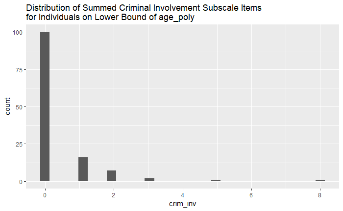

```r
#crim involvement histogram
ggplot(lb_inds, aes(x=crim_inv)) +
     geom_histogram()  +
     ggtitle("Distribution of Summed Criminal Involvement Subscale Items\nfor Individuals on Lower Bound of age_poly")
```

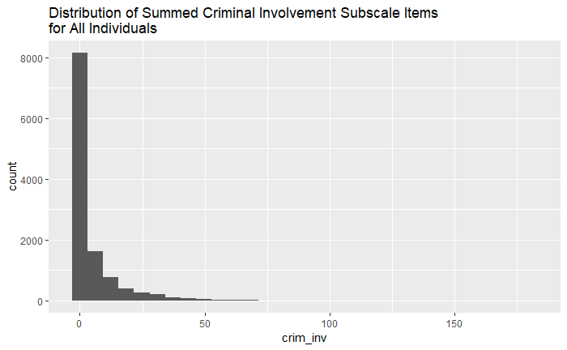

```r
#comparison histogram for all individuals who are 18-70, have scores not -1, and are above lb
ggplot(features%>%filter(filt1,filt5,filt6),
       aes(x=crim_inv)) +
     geom_histogram()  +
     ggtitle("Distribution of Summed Criminal Involvement Subscale Items\nfor All Individuals")
```

Question: of the crimes that people with a criminal involvement subscale sum of 1 or 2 committed, which ones were they? Criminal involvement subscale items: p_charge, p_jail30, p_prison, p_probation

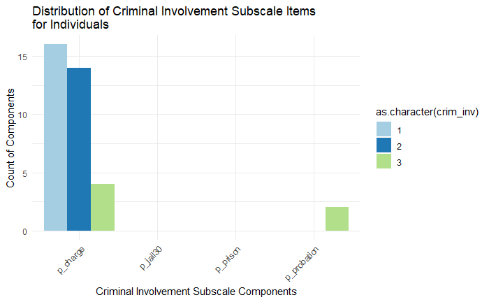

```r
age_subset_long=lb_inds%>%

               select(crim_inv,person_id,
                      p_charge,
                      p_jail30,
                      p_prison,
                      p_probation)%>%

               filter(crim_inv==2 | crim_inv==1 | crim_inv == 3)%>%
               gather(crim_inv_component,component_count,p_charge:p_probation,factor_key = T)%>%
               group_by(crim_inv, crim_inv_component)%>%
                  summarise(comp_sum = sum(component_count))
ggplot(age_subset_long, aes(x=crim_inv_component,
                            y=comp_sum,fill = as.character(crim_inv))) +
      geom_bar(stat="identity", position=position_dodge())+
      ggtitle("Distribution of Criminal Involvement Subscale Items\nfor Individuals") +
      xlab("Criminal Involvement Subscale Components") +
      ylab("Count of Components") +
      scale_fill_discrete(name = "Criminal Involvement scores")+
      scale_fill_brewer(palette="Paired")+
      theme_minimal() +
      theme(axis.text.x = element_text(angle = 45, vjust=1,hjust=1))
```

Examining the criminal history of individuals on the lower bound who had a criminal involvement subscale sum of 1. Question: what were these people charged for?

| p_current_age | crim_inv | person_id | p_charge | current_offense_date | first_offense_date | screening_date |
| --- | --- | --- | --- | --- | --- | --- |
| 60 | 1 | 9250 | 1 | 2014-05-05 | 2014-04-13 | 2014-05-06 |
| 53 | 1 | 10090 | 1 | 2014-11-03 | 2014-09-26 | 2014-11-04 |
| 51 | 1 | 7681 | 1 | 2013-06-30 | 2012-11-21 | 2013-07-02 |
| 51 | 1 | 10074 | 1 | 2014-04-02 | 2013-02-23 | 2014-04-03 |
| 50 | 1 | 10101 | 1 | 2014-11-08 | 2013-04-10 | 2014-11-09 |
| 42 | 1 | 4187 | 1 | 2014-02-14 | 2010-01-30 | 2014-02-18 |
| 41 | 1 | 2510 | 1 | 2014-09-08 | 2006-02-19 | 2014-09-09 |
| 38 | 1 | 4057 | 1 | 2014-12-01 | 2003-06-06 | 2014-12-02 |
| 31 | 1 | 3502 | 1 | 2013-08-26 | 2010-02-23 | 2013-08-27 |
| 30 | 1 | 6949 | 1 | 2014-03-08 | 2013-04-03 | 2014-03-09 |

[output cut: 6 more lines]

| p_current_age | crim_inv | person_id | p_charge | current_offense_date | first_offense_date | screening_date |
| --- | --- | --- | --- | --- | --- | --- |
| 57 | 2 | 11720 | 2 | 2013-11-01 | 1990-08-06 | 2013-11-02 |
| 40 | 2 | 9028 | 2 | 2013-08-18 | 2013-06-30 | 2013-08-19 |
| 29 | 2 | 10976 | 2 | 2014-12-19 | 2010-01-08 | 2014-12-19 |
| 27 | 2 | 2401 | 2 | 2014-03-16 | 2009-05-21 | 2014-03-17 |
| 23 | 2 | 4941 | 2 | 2013-08-23 | 2012-05-03 | 2013-08-24 |
| 23 | 2 | 8152 | 2 | 2014-07-21 | 2009-06-10 | 2014-07-22 |
| 21 | 2 | 3073 | 2 | 2014-07-22 | 2014-07-17 | 2014-07-23 |

Filtering for individuals who have NO crim inv and seeing if this makes the lower bound clearer. There are 127 total individuals on the lower bound but when we perform this operation it leaves only 100.

[figure not shown]

```r
inds_no_history = lb_inds %>%
    filter(crim_inv == 0)
# nrow(inds_no_history) #100 inds
xmin = 18
xmax = 70
xx = seq(xmin,xmax, length.out=1000)
ggplot()+
  geom_point(aes(x=p_current_age, raw_score), color="#619CFF",alpha=.3, data=inds_no_history) +
  geom_line(aes(x=xx, predict(mdl_age, newdata=data.frame(p_current_age=xx))),color="#F8766D") +
  theme_bw()+
  ggtitle("Individuals with no prior criminal involvement")+
  xlim(xmin,xmax)+
  xlab("Age at COMPAS screening date") +
  ylab("Recidivism score") +
  theme(text = element_text(size=12),
        axis.text=element_text(size=12),
        legend.position="none")
```

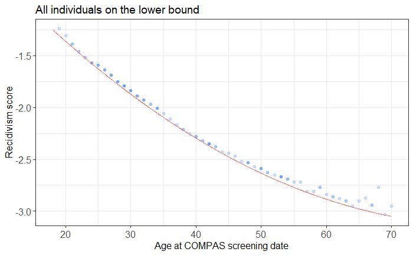

```r
ggplot()+
  geom_point(aes(x=p_current_age, raw_score), color="#619CFF",alpha=.3, data=lb_inds) +
  geom_line(aes(x=xx, predict(mdl_age, newdata=data.frame(p_current_age=xx))),color="#F8766D") +
  theme_bw()+
  ggtitle("All individuals on the lower bound")+
  xlim(xmin,xmax)+
  xlab("Age at COMPAS screening date") +
  ylab("Recidivism score") +
  theme(text = element_text(size=12),
        axis.text=element_text(size=12),
        legend.position="none")
```

```r
#Risk of Recidivism vs Age: p_current_age
ggplot(train, aes(x=p_current_age, y=`Risk of Recidivism_raw_score`)) +
     geom_point(shape=1)  +
     ggtitle("Risk of Recidivism Raw vs Current Age")


#Risk of Recidivism vs prison time: p_prison_time
ggplot(train, aes(x=p_prison_time, y=`Risk of Recidivism_raw_score`)) +
     geom_point(shape=1)  +
     ggtitle("Risk of Recidivism Raw vs Prison Time")

#Risk of Recidivism vs prison visits: p_prison_visits
ggplot(train, aes(x=p_prison_visits, y=`Risk of Recidivism_raw_score`)) +
     geom_point(shape=1)  +
     ggtitle("Risk of Recidivism Raw vs Prison Visits")

#Risk of Recidivism vs jail time: p_jail_time
ggplot(train, aes(x=p_jail_time, y=`Risk of Recidivism_raw_score`)) +
     geom_point(shape=1)  +
     ggtitle("Risk of Recidivism Raw vs Jail Time")

#Risk of Recidivism vs jail visits: p_jail_visits
ggplot(train, aes(x=p_jail_visits, y=`Risk of Recidivism_raw_score`)) +
     geom_point(shape=1)  +
     ggtitle("Risk of Recidivism Raw vs Jail Visits")
##
#Risk of Recidivism vs 5yrsFel: p_yrs5_felcount_person
ggplot(train, aes(x=p_yrs5_felcount_person, y=`Risk of Recidivism_raw_score`)) +
     geom_point(shape=1)  +
     ggtitle("Risk of Recidivism Raw vs 5yrsFel")

#Risk of Recidivism vs Total Fel: p_felony_count_person
ggplot(train, aes(x=p_felony_count_person, y=`Risk of Recidivism_raw_score`)) +
     geom_point(shape=1)  +
     ggtitle("Risk of Recidivism Raw vs Fel Count")
##
#Risk of Recidivism vs 5yrsMisdem: p_misdem_count_5yrs
ggplot(train, aes(x=p_misdem_count_5yrs, y=`Risk of Recidivism_raw_score`)) +
     geom_point(shape=1)  +
     ggtitle("Risk of Recidivism Raw vs 5yrsMisdem")

#Risk of Recidivism vs Total Misdem: p_misdem_count_person
ggplot(train, aes(x=p_misdem_count_person, y=`Risk of Recidivism_raw_score`)) +
     geom_point(shape=1)  +
     ggtitle("Risk of Recidivism Raw vs Misdem Count")
##
#Risk of Recidivism vs 5yrsDrug: p_drug_count_5yrs
ggplot(train, aes(x=p_drug_count_5yrs, y=`Risk of Recidivism_raw_score`)) +
     geom_point(shape=1)  +
     ggtitle("Risk of Recidivism Raw vs 5yrsDrug")

#Risk of Recidivism vs Total Drug: p_drug_count_person
ggplot(train, aes(x=p_drug_count_person, y=`Risk of Recidivism_raw_score`)) +
     geom_point(shape=1)  +
     ggtitle("Risk of Recidivism Raw vs Drug Count")
##
#Risk of Recidivism vs 5yrsTraffic: p_yrs5_trafcount_person
ggplot(train, aes(x=p_yrs5_trafcount_person, y=`Risk of Recidivism_raw_score`)) +
     geom_point(shape=1)  +
     ggtitle("Risk of Recidivism Raw vs 5yrsTraffic")

#Risk of Recidivism vs Total Traffic: p_traffic_count_person
ggplot(train, aes(x=p_traffic_count_person, y=`Risk of Recidivism_raw_score`)) +
     geom_point(shape=1)  +
     ggtitle("Risk of Recidivism Raw vs Traffic Count")

#Risk of Recidivism vs prior violent convictions: cq_violent_conviction
ggplot(train, aes(x=cq_violent_conviction, y=`Risk of Recidivism_raw_score`)) +
     geom_point(shape=1)  +
     ggtitle("Risk of Recidivism Raw vs Violent Convictions")

#Risk of Recidivism vs Total Convictions: cq_total_convictions
ggplot(train, aes(x=cq_total_convictions, y=`Risk of Recidivism_raw_score`)) +
     geom_point(shape=1)  +
     ggtitle("Risk of Recidivism Raw vs Total Convictions")

#Risk of Recidivism vs Number of Cases: p_numcases
ggplot(train, aes(x=p_numcases, y=`Risk of Recidivism_raw_score`)) +
     geom_point(shape=1)  +
     ggtitle("Risk of Recidivism Raw vs Number of Cases")

#Risk of Recidivism  and number of failures to appear in 2 yrs:cq_fail_appear_two_yr
ggplot(train, aes(x=cq_fail_appear_two_yr, y=`Risk of Recidivism_raw_score`)) +
     geom_point(shape=1)  +
     ggtitle("Risk of Recidivism Raw vs #Failure to appear in 2 yrs")

#Risk of Recidivism  and number of failures to appear in 2 yrs plus: cq_fail_appear_two_plus
ggplot(train, aes(x=cq_fail_appear_two_plus, y=`Risk of Recidivism_raw_score`)) +
     geom_point(shape=1)  +
     ggtitle("Risk of Recidivism Raw vs #Failure to appear in >2 yrs")

#Risk of Recidivism  and total number of failures to appear
ggplot(train, aes(x=cq_fail_appear_two_yr+cq_fail_appear_two_plus, y=`Risk of Recidivism_raw_score`)) +
     geom_point(shape=1)  +
     ggtitle("Risk of Recidivism Raw vs Total# Failure to appear")

#Risk of Recidivism vs race: p_race
ggplot(train, aes(x=p_race, y=`Risk of Recidivism_raw_score`)) +
     geom_point(shape=1)  +
     ggtitle("Risk of Recidivism Raw vs Race")

#Risk of Recidivism vs sex: p_sex
ggplot(train, aes(x=p_sex, y=`Risk of Recidivism_raw_score`)) +
     geom_point(shape=1)  +
     ggtitle("Risk of Recidivism Raw vs Sex")

#Risk of Recidivism vs marital status
ggplot(train, aes(x=p_marital_status, y=`Risk of Recidivism_raw_score`)) +
     geom_point(shape=1)  +
     ggtitle("Risk of Recidivism Raw vs Marital Status")
```

[output not shown]

Plot of number of misdemeanors vs compas “remainder”

```r
ggplot(train, aes(x=pmin(p_jail30,5),
                     y=`Risk of Recidivism_raw_score`-age_poly_recid(p_current_age))) +
     geom_point(shape=1)  +
     xlab("\n30 day Jail Visits per Person") +
     ylab("COMPAS General Recidivism Remainde\nr")+
     xlim(0,5)+
     theme(text=element_text(size=17),
           axis.ticks=element_line(size=1),
           axis.ticks.length = unit(3, "mm"))

ggplot(train, aes(x=p_arrest,
                     y=`Risk of Recidivism_raw_score`-age_poly_recid(p_current_age))) +
     geom_point(shape=1)  +
     xlab("\nArrests per Person") +
     ylab("COMPAS General Recidivism\nRemainder")+
     xlim(0,25)+
     theme(text=element_text(size=17),
           axis.ticks=element_line(size=1),
           axis.ticks.length = unit(3, "mm"))

ggplot(train, aes(x=pmin(p_prison,5),
                     y=`Risk of Recidivism_raw_score`-age_poly_recid(p_current_age))) +
     geom_point(shape=1)  +
     xlab("\nPrison Visits per Person") +
     ylab("COMPAS General Recidivism Remainder\n")+
     xlim(0,5)+
     theme(text=element_text(size=17),
           axis.ticks=element_line(size=1),
           axis.ticks.length = unit(3, "mm"))

ggplot(train, aes(x=p_probation,
                     y=`Risk of Recidivism_raw_score`-age_poly_recid(p_current_age))) +
     geom_point(shape=1)  +
     xlab("\nProbation per Person") +
     ylab("COMPAS General Recidivism Remainder\n")+
     xlim(0,5)+
     theme(text=element_text(size=17),
           axis.ticks=element_line(size=1),
           axis.ticks.length = unit(3, "mm"))
```

[output not shown]